# Ford GoBike

## by Gabriela Garcia

## Investigation Overview

> My goal is to visualize the variance in use of the Ford GoBikes by user type, month, and station pairs.

## Dataset Overview

> Ford GoBike is a bike sharing service available in the San Francisco Bay area. Their service has been available in the San Francisco area since 2013, I will be exploring data about this bike sharing service from the year 2018. It is a public bike sharing system that is only available regionally. The data I will be presenting is from the year 2018, it is sectioned by month, and it contains information on each bike use instance. I will be looking at the user type (single use customer or long term subscriber), month, and station pairs for these instances.

## Total Rides per Month

> This is a bar chart of Ford GoBike total uses per month. In the barchart we can see a large increase in use over the summer months, as well as october being the most popular month for bike use.

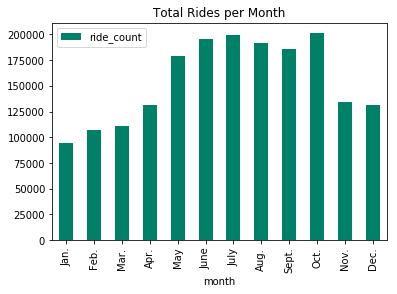

```python
#plotting the monthly data
df_rides_per_month.ride_count = df_rides_per_month.ride_count.astype(int)
df_rides_per_month.plot.bar(x='month', y='ride_count', colormap='summer', title='Total Rides per Month');
```

## Customer vs. Subscriber use for Popular Station Pairs from Month to Month

> This is a set of scatter plots to represent each month in 2018. The plots show uses for popular stations, where start station use is on the x axis and end station use is on the y axis. The opacity of the point shows the frequency or popularity of that start/stop station pair, while the stronger of the two colors shows if these instances we're mostly customer or subscirber uses. In these plots Orange is a subsriber use instance and Blue is a customer use instance.

> We can see how Customer use variaes and migrates from different station pairs during each month of the year. Some stations and some months seem to be more popular for customer use than others.

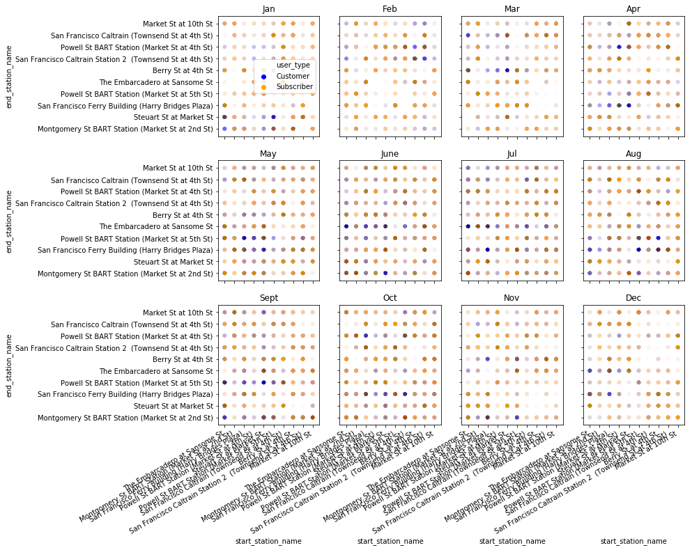

```python
#plotting sub plots
f,((ax1,ax2,ax3,ax4),(ax5,ax6,ax7,ax8),(ax9,ax10,ax11,ax12)) = plt.subplots(3,4, sharex=True, sharey=True, figsize=(12,12))
ax1.set_title('Jan')
ax2.set_title('Feb')
ax3.set_title('Mar')
ax4.set_title('Apr')
ax5.set_title('May')
ax6.set_title('June')
ax7.set_title('Jul')
ax8.set_title('Aug')
ax9.set_title('Sept')
ax10.set_title('Oct')
ax11.set_title('Nov')
ax12.set_title('Dec')
sb.scatterplot(data = df01[df01.start_station_name.isin(most_popular)][df01.end_station_name.isin(most_popular)], x = df01.start_station_name, y = df01.end_station_name, alpha=1/100, hue = 'user_type', palette = {'Customer':'blue', 'Subscriber':'orange'}, legend='brief', ax=ax1).figure.autofmt_xdate();
sb.scatterplot(data = df02[df02.start_station_name.isin(most_popular)][df02.end_station_name.isin(most_popular)], x = df02.start_station_name, y = df02.end_station_name, alpha=1/100, hue = 'user_type', palette = {'Customer':'blue', 'Subscriber':'orange'}, legend=False, ax=ax2).figure.autofmt_xdate();
sb.scatterplot(data = df03[df03.start_station_name.isin(most_popular)][df03.end_station_name.isin(most_popular)], x = df03.start_station_name, y = df03.end_station_name, alpha=1/100, hue = 'user_type', palette = {'Customer':'blue', 'Subscriber':'orange'}, legend=False, ax=ax3).figure.autofmt_xdate();
sb.scatterplot(data = df04[df04.start_station_name.isin(most_popular)][df04.end_station_name.isin(most_popular)], x = df04.start_station_name, y = df04.end_station_name, alpha=1/100, hue = 'user_type', palette = {'Customer':'blue', 'Subscriber':'orange'}, legend=False, ax=ax4).figure.autofmt_xdate();
sb.scatterplot(data = df05[df05.start_station_name.isin(most_popular)][df05.end_station_name.isin(most_popular)], x = df05.start_station_name, y = df05.end_station_name, alpha=1/100, hue = 'user_type', palette = {'Customer':'blue', 'Subscriber':'orange'}, legend=False, ax=ax5).figure.autofmt_xdate();
sb.scatterplot(data = df06[df06.start_station_name.isin(most_popular)][df06.end_station_name.isin(most_popular)], x = df06.start_station_name, y = df06.end_station_name, alpha=1/100, hue = 'user_type', palette = {'Customer':'blue', 'Subscriber':'orange'}, legend=False, ax=ax6).figure.autofmt_xdate();
sb.scatterplot(data = df07[df07.start_station_name.isin(most_popular)][df07.end_station_name.isin(most_popular)], x = df07.start_station_name, y = df07.end_station_name, alpha=1/100, hue = 'user_type', palette = {'Customer':'blue', 'Subscriber':'orange'}, legend=False, ax=ax7).figure.autofmt_xdate();
sb.scatterplot(data = df08[df08.start_station_name.isin(most_popular)][df08.end_station_name.isin(most_popular)], x = df08.start_station_name, y = df08.end_station_name, alpha=1/100, hue = 'user_type', palette = {'Customer':'blue', 'Subscriber':'orange'}, legend=False, ax=ax8).figure.autofmt_xdate();
sb.scatterplot(data = df09[df09.start_station_name.isin(most_popular)][df09.end_station_name.isin(most_popular)], x = df09.start_station_name, y = df09.end_station_name, alpha=1/100, hue = 'user_type', palette = {'Customer':'blue', 'Subscriber':'orange'}, legend=False, ax=ax9).figure.autofmt_xdate();
sb.scatterplot(data = df10[df10.start_station_name.isin(most_popular)][df10.end_station_name.isin(most_popular)], x = df10.start_station_name, y = df10.end_station_name, alpha=1/100, hue = 'user_type', palette = {'Customer':'blue', 'Subscriber':'orange'}, legend=False, ax=ax10).figure.autofmt_xdate();
sb.scatterplot(data = df11[df11.start_station_name.isin(most_popular)][df11.end_station_name.isin(most_popular)], x = df11.start_station_name, y = df11.end_station_name, alpha=1/100, hue = 'user_type', palette = {'Customer':'blue', 'Subscriber':'orange'}, legend=False, ax=ax11).figure.autofmt_xdate();
sb.scatterplot(data = df12[df12.start_station_name.isin(most_popular)][df12.end_station_name.isin(most_popular)], x = df12.start_station_name, y = df12.end_station_name, alpha=1/100, hue = 'user_type', palette = {'Customer':'blue', 'Subscriber':'orange'}, legend=False, ax=ax12).figure.autofmt_xdate();
#blue = customer, orange = subscriber
```

## Heat Maps of Station Pairs from Month to Month

> This visualization is a heatmap of similiar data that was found in the scatter plots but we are able to see better indicators of the popularity of station pairs using the colr mapping. The dark colors represent low frequency while the colorful colors move from pink to orange to show higher frequency, and the cells that are white represent the max or most used station pairs.

> We can see that a lot of the most popular station pairs stay the same from month to month, but one notable difference is that there are more pink and orange cells in the Sept - Dec row. The values here are relative so this is not related to the popularity of the month its self but rather the variance and increase of certain routes during these months.

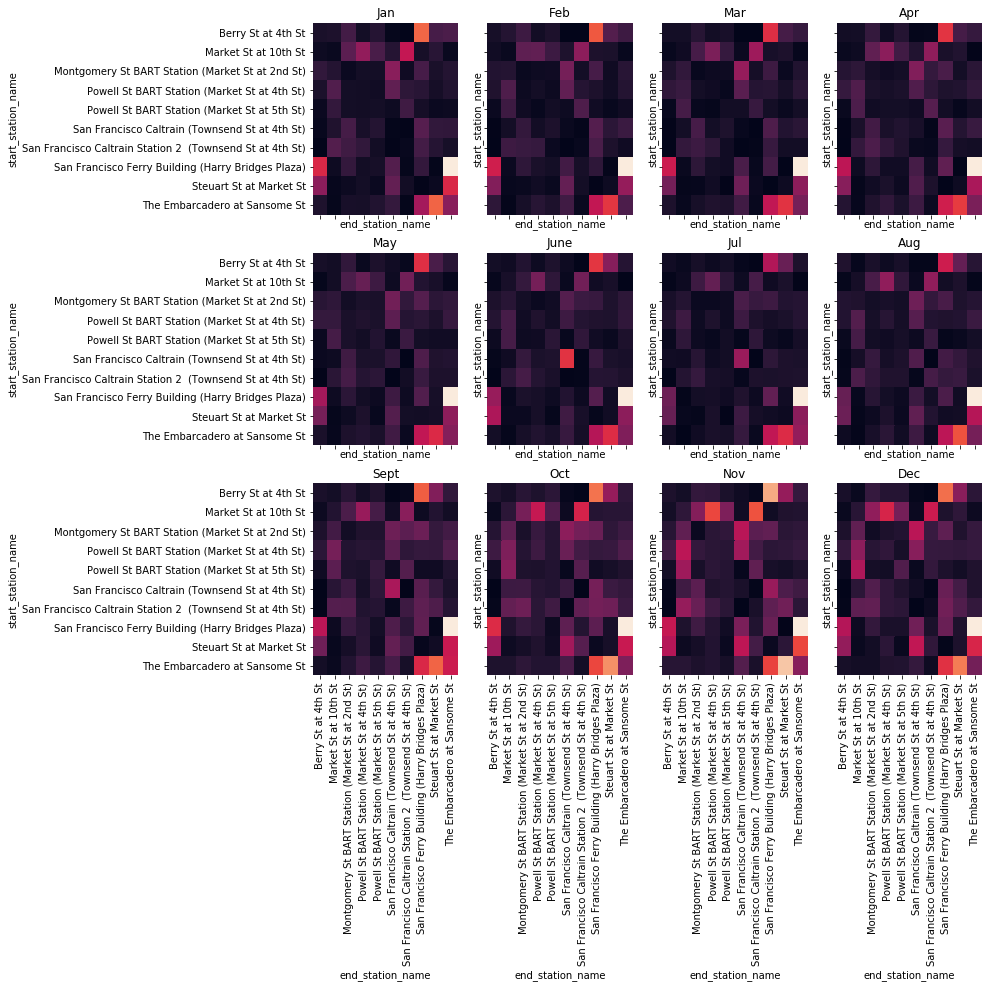

```python
f,((ax1,ax2,ax3,ax4),(ax5,ax6,ax7,ax8),(ax9,ax10,ax11,ax12)) = plt.subplots(3,4, sharex=True, sharey=True, figsize=(12,12))
ax1.set_title('Jan')
ax2.set_title('Feb')
ax3.set_title('Mar')
ax4.set_title('Apr')
ax5.set_title('May')
ax6.set_title('June')
ax7.set_title('Jul')
ax8.set_title('Aug')
ax9.set_title('Sept')
ax10.set_title('Oct')
ax11.set_title('Nov')
ax12.set_title('Dec')
sb.heatmap(df01_refined,cbar=False, ax=ax1);
sb.heatmap(df02_refined,cbar=False, ax=ax2);
sb.heatmap(df03_refined,cbar=False, ax=ax3);
sb.heatmap(df04_refined,cbar=False, ax=ax4);
sb.heatmap(df05_refined,cbar=False, ax=ax5);
sb.heatmap(df06_refined,cbar=False, ax=ax6);
sb.heatmap(df07_refined,cbar=False, ax=ax7);
sb.heatmap(df08_refined,cbar=False, ax=ax8);
sb.heatmap(df09_refined,cbar=False, ax=ax9);
sb.heatmap(df10_refined,cbar=False, ax=ax10);
sb.heatmap(df11_refined,cbar=False, ax=ax11);
sb.heatmap(df12_refined,cbar=False, ax=ax12);
```

## Conclusion

> Overall my visualizations can be used to track customer trends and migrations during certain months of the year. The variation of customer use and increased diversity in station pairs during certain months could be signs of weather trends, increased tourist use, or seasonal attractions and events.